# Brazil Highway Traffic Accidents

A Polícia Rodoviária Federal mapeou os acidentes em rodovias no ano de 2020. Temos dados de vítimas envolvidas, qual a rodovia, data, horário, km, causa do acidente, tipo, classificação, tipo de pista, e a quantidade de veículos envolvidos.

Tivemos um total de 63548 acidentes em rodovias contabilizados no ano de 2020, sendo uma média de 174 por dia. Tivemos um máximo de 289 em 2020-12-19, e um mínimo de 70 em 2020-03-23.

Tivemos mais de 6 mil acidentes nos meses de dezembro e outubro, e o mês de abril registrou a menor quantidade de acidentes, com 3883. Dentro das estações do ano, temos que a Primavera é a que concentra a maior quantidade de acidentes, e o Outono tem a menor quantidade, tendo uma diferença de 5 mil acidentes entre elas. Verão e Inverno estão praticamente empatadas na segunda colocação com pouco menos de mil acidentes a menos que na Primavera.

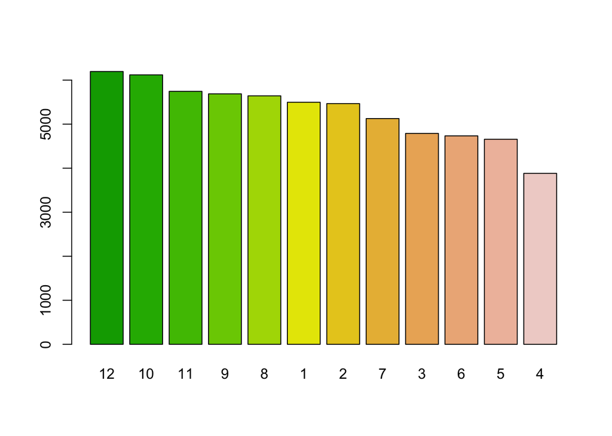

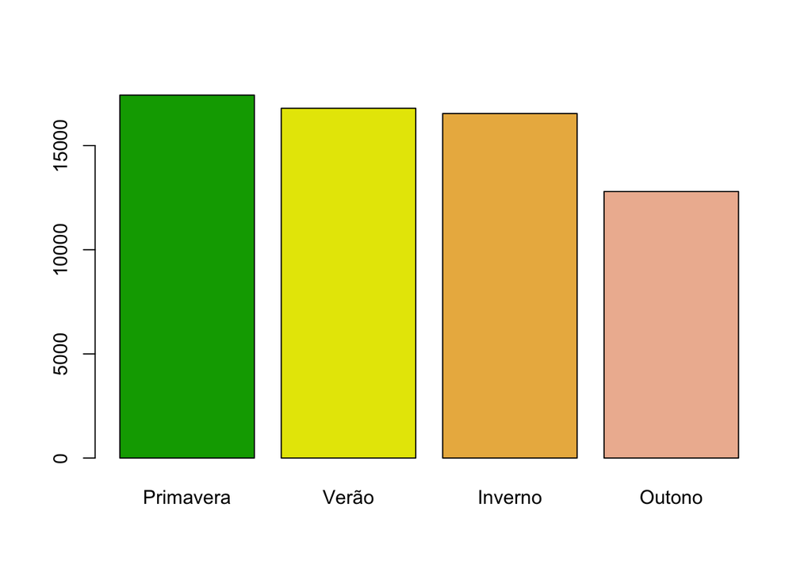

Tivemos um total de 5291 vítimas fatais, sendo o acidente com a maior quantidade de fatalidades totalizando 13, no dia 2020-12-04. Também um total de 71480 feridos, com o acidente acontecendo no dia 2020-04-15 tendo a maior quantidade de vítimas, com 44.

Tivemos 59025 (93%) acidentes sem vítimas fatais, e 14439 (22.7%) sem pessoas feridas.

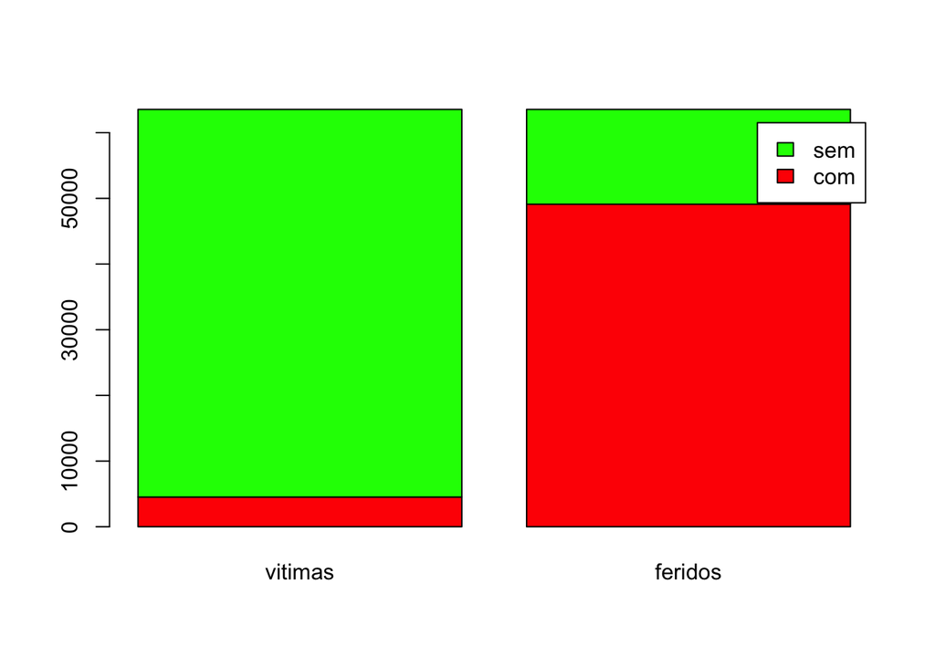

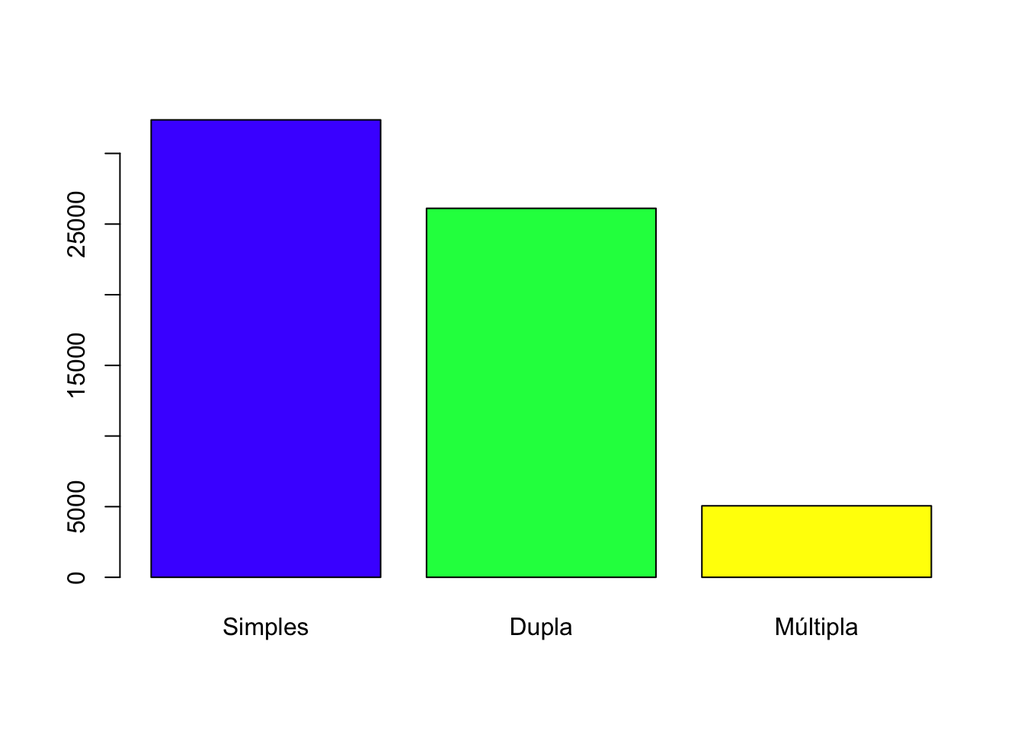

Acidentes de dia são mais frequentes, com quase 35 mil das ocorrências, seguindo de acidentes a noite, com 23 mil. Acidentes ao amanhecer e anoitecer somam pouco mais de 6 mil.

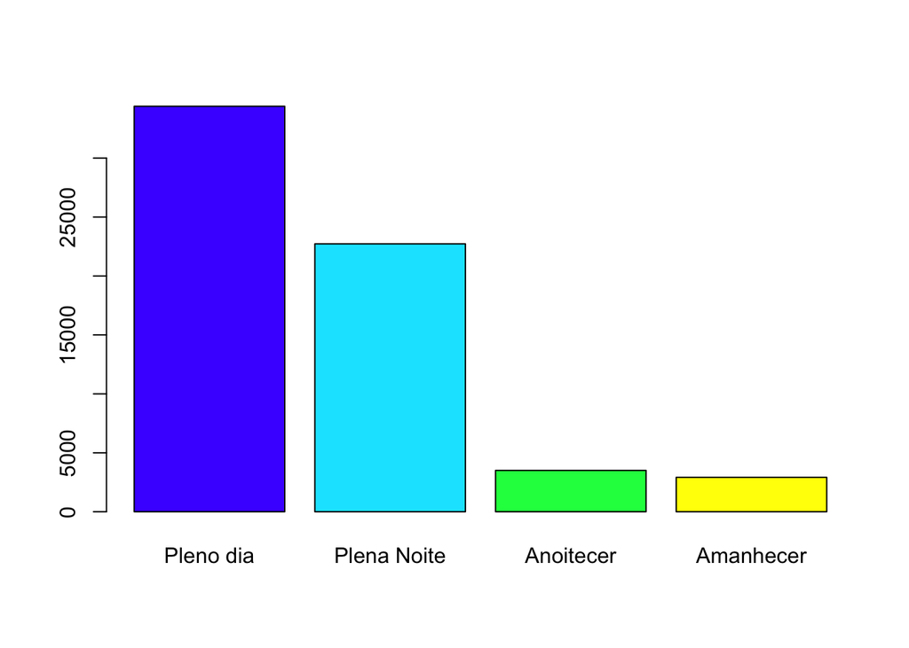

O estado com mais acidentes é Minas Gerais, com 8.3 mil. Os estados do Acre, Roraima, Amapá e Amazonas têm menos de 300 acidentes cada. A região Sudeste lidera com 19 mil acidentes, seguida pela região Sul com 18.5 mil. A região Norte soma menos de 4 mil acidentes. A cidade de Brasília soma mais de mil acidentes, seguida de Curitiba com 950.

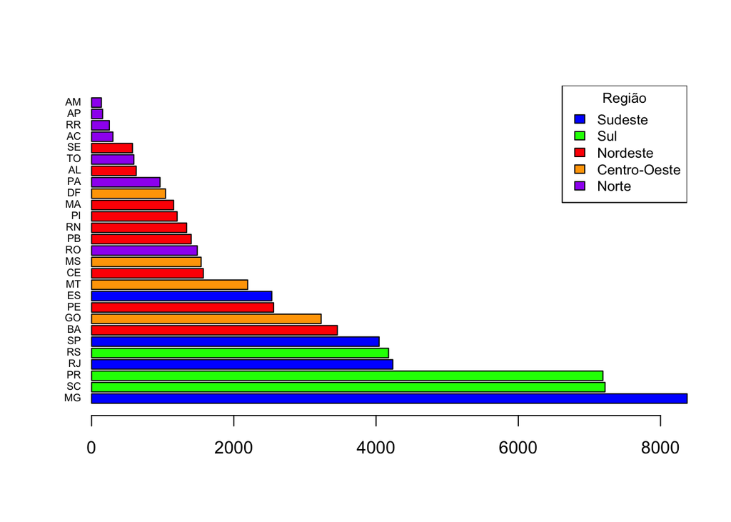

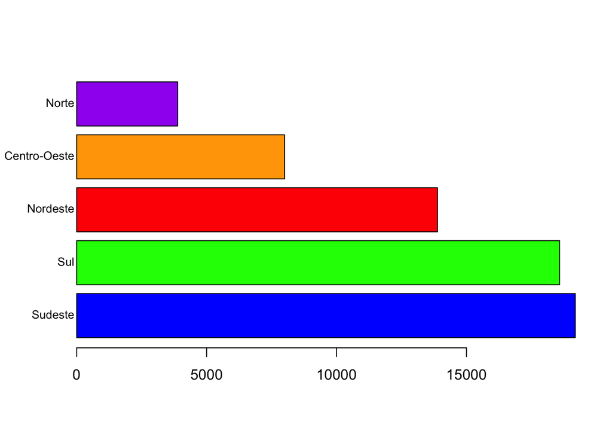

### Vítimas em acidentes varia entre os tipos de pista?

**Hipótese nula**: Simples = Dupla = Múltipla

**Hipótese alternativa**: Algum diferente

Nenhuma das distribuições é normal.

```
##
##  Kruskal-Wallis rank sum test
##
## data:  mortos_e_feridos by tipo_pista
## Kruskal-Wallis chi-squared = 337.68, df = 2, p-value < 2.2e-16
```

```
##   Kruskal-Wallis rank sum test
##
## data: x and group
## Kruskal-Wallis chi-squared = 337.6751, df = 2, p-value = 0
##
##
##                            Comparison of x by group
##                                  (Bonferroni)
## Col Mean-|
## Row Mean |      Dupla   Múltipla
## ---------+----------------------
## Múltipla |   1.266131
##          |     0.3082
##  Simples |  -17.10986  -10.70072
##          |    0.0000*    0.0000*
##
## alpha = 0.05
## Reject Ho if p <= alpha/2
```

Há diferença significativa entre Simples e Dupla, e Simples e Múltipla. Não há diferença significative entre Dupla e Múltipla.

### A proporção de acidentes com vítimas é maior aos finais de semana do que em dias úteis?

**Hipótese nula**: Final de Semana igual Dias Úteis

**Hipótese alternativa**: Final de Semana diferente Dias Úteis

Nenhuma das distribuições é normal.

```
##
##  Wilcoxon rank sum test with continuity correction
##
## data:  mortos_e_feridos by dia_semana_adj
## W = 440836442, p-value = 0.0004372
## alternative hypothesis: true location shift is not equal to 0
```

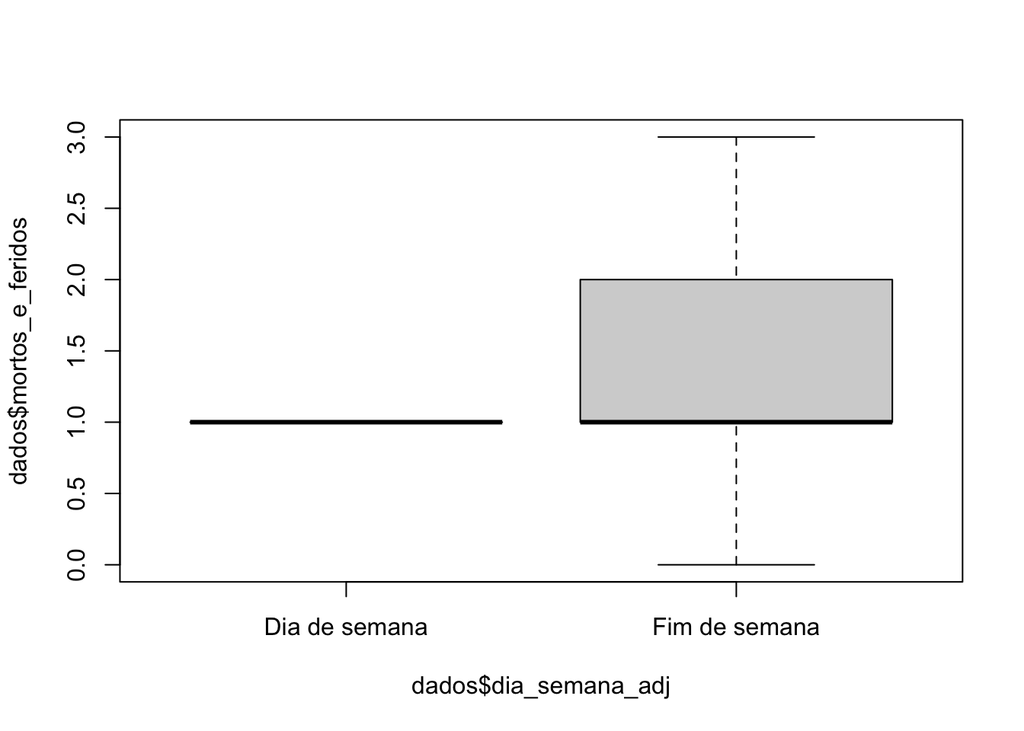

Há diferença significativa entre fim de semana e dia útil.

### A fase do dia influencia o número de vítimas?

**Hipótese nula**: Pleno dia == Pleno noite == Amanhecer == Anoitecer

**Hipótese alternativa**: Algum diferente

Nenhuma das distribuições é normal.

```
##
##  Kruskal-Wallis rank sum test
##
## data:  mortos_e_feridos by fase_dia
## Kruskal-Wallis chi-squared = 147.04, df = 3, p-value < 2.2e-16
```

```
##   Kruskal-Wallis rank sum test
##
## data: x and group
## Kruskal-Wallis chi-squared = 147.0398, df = 3, p-value = 0
##
##
##                            Comparison of x by group
##                                  (Bonferroni)
## Col Mean-|
## Row Mean |   Amanhece   Anoitece   Plena No
## ---------+---------------------------------
## Anoitece |  -4.812518
##          |    0.0000*
## Plena No |  -0.078655   6.562759
##          |     1.0000    0.0000*
## Pleno di |  -5.008266   1.354306  -11.11713
##          |    0.0000*     0.5269    0.0000*
##
## alpha = 0.05
## Reject Ho if p <= alpha/2
```

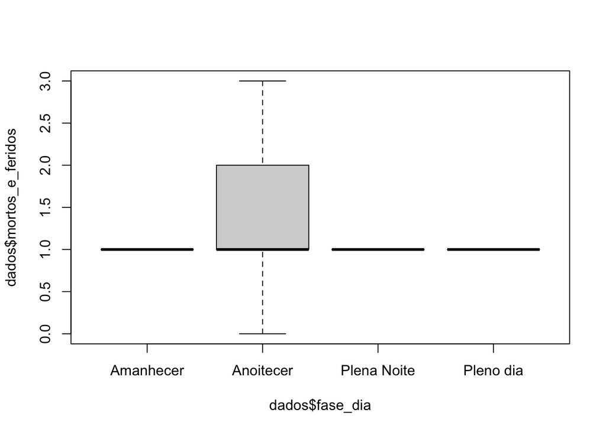

Há diferença significativa entre:

- Anoitecer e Amanhecer
- Anoitecer e Plena Noite
- Pleno Dia e Amanhecer
- Pleno Dia e Plena Noite

Não há diferença significative entre:

- Amanhecer e Plena Noite
- Anoitecer e Pleno Dia

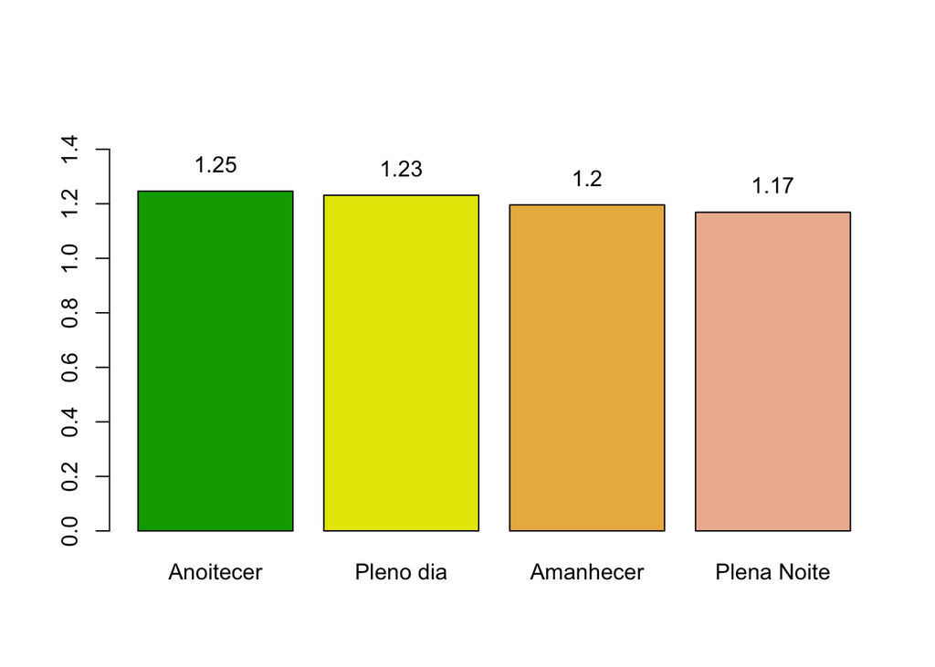

### Existe alguma correlação entre mortos e feridos

**Hipótese nula**: Variáveis são independentes

**Hipótese alternativa**: Variáveis são dependentes

Nenhuma distribuição é normal.

```
## [1] -0.02425205
```

```
##
##  Spearman's rank correlation rho
##
## data:  dados$mortos and dados$feridos
## S = 5.0635e+13, p-value < 2.2e-16
## alternative hypothesis: true rho is not equal to 0
## sample estimates:
##        rho
## -0.1838415
```

Correlação muito fraca, e estatisticamente significativa.

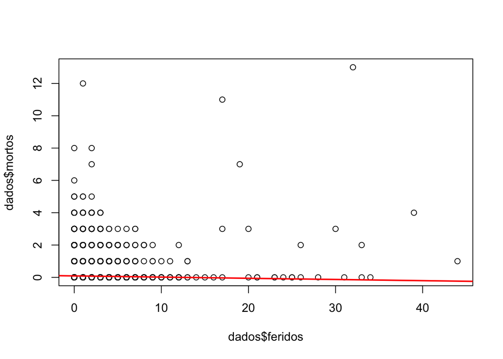

### Verificar proporção entre mortos em conduta do pedestre e outras causas

**Hipótese nula**: Proporção mortos em conduta do pedestre == Proporção mortos em outros

**Hipótese alternativa**: Proporção mortos em conduta do pedestre != Proporção mortos em outros

Para este teste, foi utilizado o Chat GPT para agrupar a causa do acidente entre as seguintes categorias:

- Conduta do Condutor
- Conduta do Pedestre
- Condições da Via
- Falhas no Veículo
- Fatores Naturais
- Imprevistos Externos
- Problemas Médicos

```
## # A tibble: 7 × 5
##   grupo_causa           soma mortos feridos count
##   <chr>                <int>  <int>   <int> <int>
## 1 Conduta do Condutor  60125   3878   56247 49197
## 2 Falhas no Veículo     5373    258    5115  5221
## 3 Condições da Via      4916    227    4689  3686
## 4 Conduta do Pedestre   2801    695    2106  2394
## 5 Imprevistos Externos  1940     95    1845  1752
## 6 Fatores Naturais       885     64     821   712
## 7 Problemas Médicos      731     74     657   586
```

```
##            grupo_causa mortos feridos mortos_e_feridos perc_mortos perc_feridos
## 1     Condições da Via    227    4689             4916       4.29%        6.56%
## 2  Conduta do Condutor   3878   56247            60125      73.29%       78.69%
## 3  Conduta do Pedestre    695    2106             2801      13.14%        2.95%
## 4    Falhas no Veículo    258    5115             5373       4.88%        7.16%
## 5     Fatores Naturais     64     821              885       1.21%        1.15%
## 6 Imprevistos Externos     95    1845             1940        1.8%        2.58%
## 7    Problemas Médicos     74     657              731        1.4%        0.92%
##   perc_mef quantidade perc_quantidade
## 1     6.4%       3686              6%
## 2   78.32%      49197             77%
## 3    3.65%       2394              4%
## 4       7%       5221              8%
## 5    1.15%        712              1%
## 6    2.53%       1752              3%
## 7    0.95%        586              1%
```

Temos que apenas 4% dos acidentes foi causado por Conduta do Pedestre, mas soma 13% das mortes.

```
##
##  2-sample test for equality of proportions with continuity correction
##
## data:  c(x1, x2) out of c(n1, n2)
## X-squared = 1742.2, df = 1, p-value < 2.2e-16
## alternative hypothesis: two.sided
## 95 percent confidence interval:
##  0.2053757 0.2422373
## sample estimates:
##     prop 1     prop 2
## 0.28654971 0.06274324
```

A diferença é significante, sendo a proporção causada pelo erro do pedestre **maior**. Sendo a diferença também estatisticamente significativa.

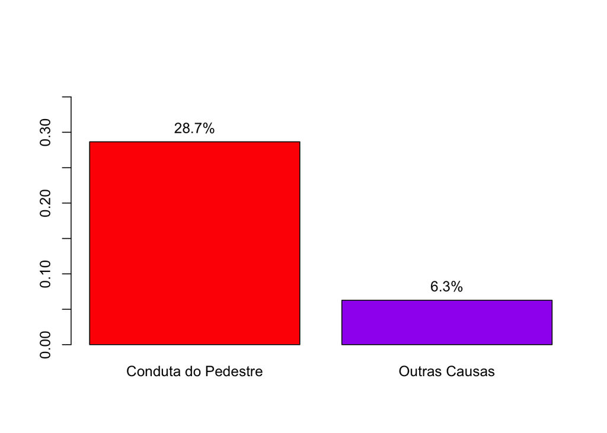